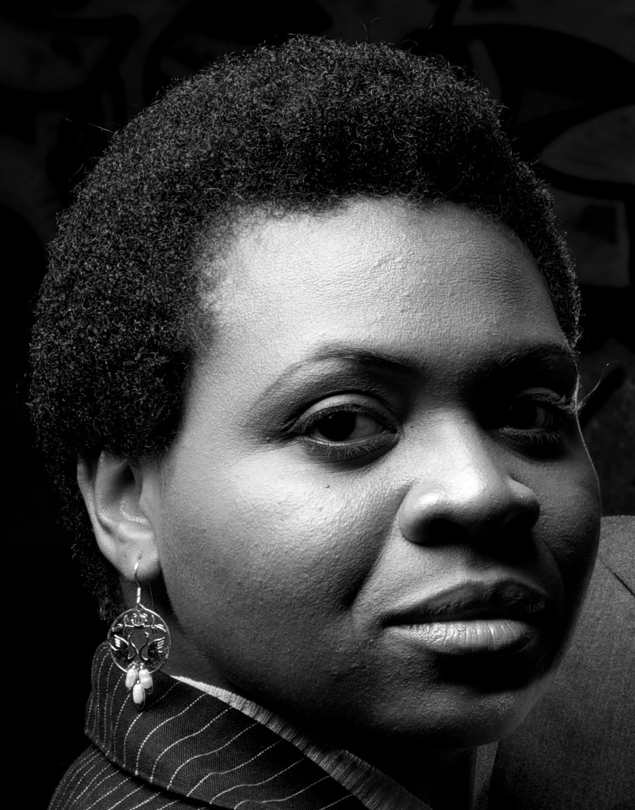

# Sarada Thomas

I am a 5th year undergrad working on concurrent degrees in the Architecture and Anthropology departments at the University of Oregon. I specialize in cultural anthropology and am minoring in Planning, Public Policy, and Management.

My research centers around elevating and learning from African American ingenuity to develop strategies for community and economic development at the community and government policy and action levels. My current research examines several Freedom colonies and towns in search of patterns and processes that created successful, prosperous and sustainable communities in the midst of privation and a hostile social and political environment.

Due to my interest in social justice and anti-racism work I have participated for the last two years in Rehearsals for Life, an improv troupe using the “Theater of the Oppressed” modality to provide opportunity for our audience to practice bystander intervention.

I am a recording artist, a designer and maker, and playwright. As a recording artist I have appeared as lead and backup vocalist on several albums and am working towards the release of my first solo album, “Blackbird Calendar”. The album is based on the multi-media performance piece of the same name completed in 2019.

As an author I am midway through a book of poetry and about 1/4 of the way through a screenplay that explores the legal origins of White as a human category.